# Multi-species interaction: a prey-predator model

Saang-Yoon Hyun  
College of Fisheries Sciences  
Pukyong National University

May 17, 2019

# Reading:

1. Chapter 3. Nonlinear models of interactions in **Allman** and **Rhodes**. Mathematical models in biology, An Introduction. Cambridge.

# Objectives

1. Introduction to Lotka-Volterra’s prey-predator model
2. Non-dimensionlization
3. Methods for numerical solving a differential equation:  
   (1) Euler,  
   (2) Modified Euler (aka Runge-Kutta method)

# Prey and predator relationship

A prey and predator relationship in a terrestrial ecosystem was relatively well reported and mathematically modeled.

Cf. That in an aquatic ecosystem is not so obvious because a multi-species relationship in an aquatic ecosystem tends to be in a food web rather than in a food chain.

# Example 1: Lemming and weasel populations

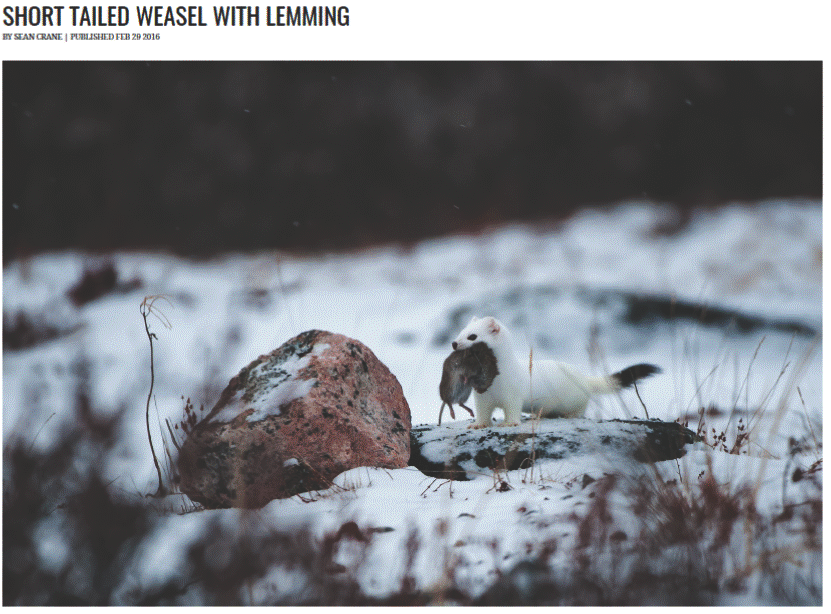

# Example 1: Lemming and weasel populations

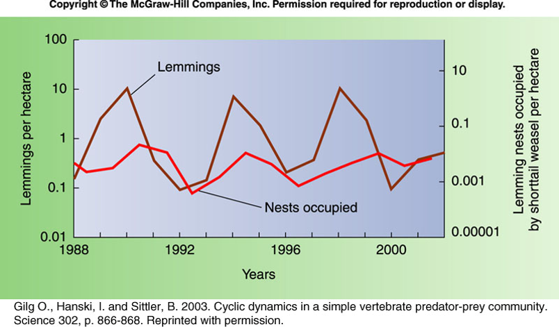

Cycles of two populations

# Example 2: Hare and lynx populations

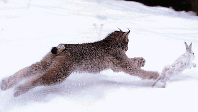

Source: https://services.math.duke.edu/education/webfeats/Word2HTML/Predator.html

# Example 2: Hare and lynx populaitons

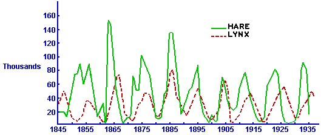

Source: https://services.math.duke.edu/education/webfeats/Word2HTML/Predator.html

# Lotka-Volterr’s prey-predator system

One of the most famous prey-predator models is Lotka-Volterra’s model.

$$\frac{dN_t}{dt} = a\cdot N_t - b\cdot N_t\cdot P_t= N_t \cdot (a-b\cdot P_t)$$

$$\frac{dP_t}{dt} = c \cdot P_t\cdot N_t - d\cdot P_t= P_t \cdot (c\cdot N_t-d)$$

where $N_t$ = a population size of a prey species at time t, and

$P_t$ = a population size of a predator species at time t.

*a*, *b*, *c*, and *d* are positive constants.

# A non-dimensional form of the original Lotka-Volterr’s prey-predator system

By $u \equiv \frac{cN_t}{d}$, $v \equiv \frac{bP_t}{a}$, $\tau \equiv at$, $\alpha \equiv \frac{d}{a}$
$$\begin{equation}
\tag{1}
\frac{du_\tau}{d\tau} = u_\tau(1-v_\tau)
\end{equation}$$

$$\begin{equation}
\tag{2}
\frac{dv_\tau}{d\tau} = \alpha v_\tau(u_\tau-1)
\end{equation}$$

# Solving the system (eqs. 1 and 2) for $u_\tau$ and $v_\tau$: a numerical approxmiation

The system (eqs. 1 and 2) cannot be analytically solved. Instead, several numerical methods had been used.  
To convince students of how to numerically solve a system that consists of differential equations, I introduce two methods:  
(1) Euler method  
(2) Modified Euler method, which is universally accepted.

# A numerical approximation: Euler method

Consider a general differential equation
$$\frac{dY_t}{dt} = f(Y_t)$$

where $Y_t$ = a quantity that varies over time t; $t$ = time; and $f(Y_t)$ is an arbitrary function.  
Approximation by Euler method:

$$\begin{align}
Y_{a+\Delta t} &\approx Y_a + {\left.\frac{dY_t}{dt}\right|}_{t=a}\cdot \Delta t \\ \\
&= Y_a + f(Y_a)\cdot \Delta t
\end{align}$$

# A graphic illustration of Euler method

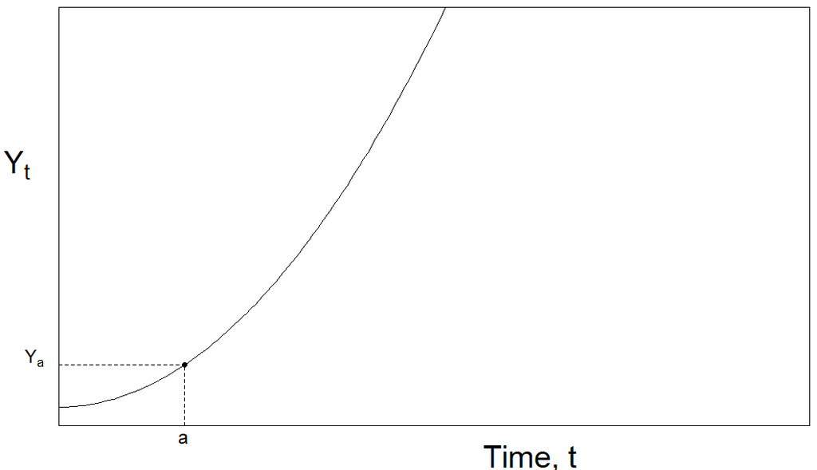

# A graphic illustration of Euler method

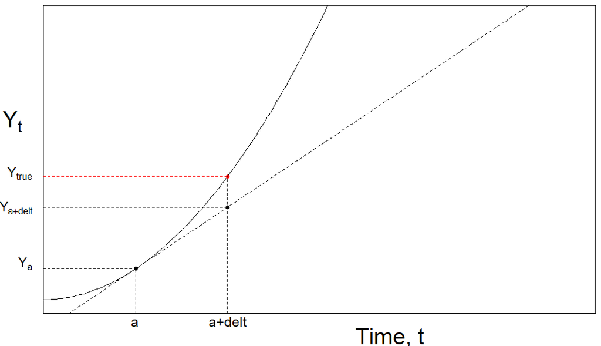

# Euler method for a non-dimensional form of Lotka-Volterra model (eqs. 1 and 2)

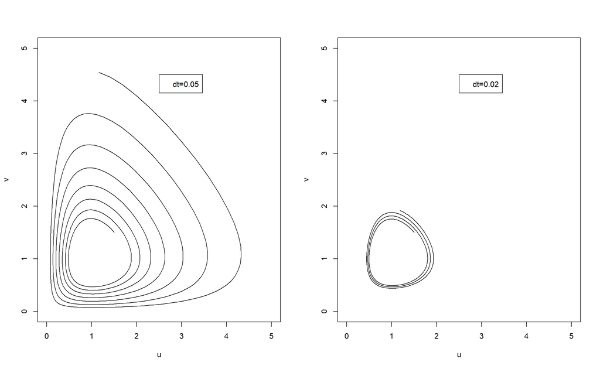

Simulation of two species by different $\Delta$ t

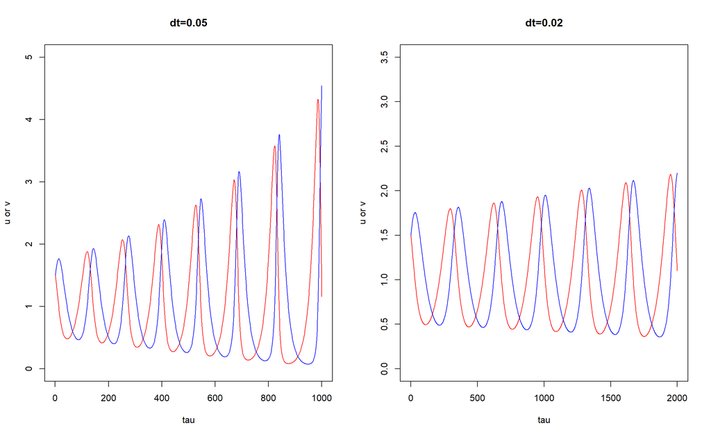

Simulation of two species by different $\Delta$ t

```r
LV.f=function(u1=1.5, v1=1.5, a=1, dt=0.2, iter)  {
  #Using Euler method;
  u=c();
  v=c();
  u[1]=u1;
  v[1]=v1;
  #
  for(i in 1:iter)   {
    u[i+1]=u[i]+u[i]*(1-v[i])*dt;
    v[i+1]=v[i]+a*v[i]*(u[i]-1)*dt;
  };
  return(data.frame(u,v));
};
```

# A numerical approximation: Modified Euler method (aka Runge-Kutta method)

Consider a general differential equation
$$\frac{dY_t}{dt} = f(Y_t)$$

where $Y_t$ = a quantity that varies over time t; $t$ = time; and $f(Y_t)$ is an arbitrary function.  
Approximation by Euler method:

$$\begin{align}
Y_{a+\Delta t} &\approx Y_a + \frac{1}{2}\cdot \left[ \left.\frac{dY_t}{dt} \right|_{t=a} +
\left. \frac{dY_t}{dt} \right|_{t=a+\Delta t}
\right] \cdot \Delta t \\ \\
&= Y_a + \frac{1}{2}\left[ f(Y_a) + f(Y_{a+\Delta t}) \right] \cdot \Delta t
\end{align}$$

# Modified Euler method for a non-dimensional form of Lotka-Volterra model (eqs. 1 and 2)

```r
#modified Euler method
LV1.f=function(u1 = 0.5, v1 = 0.5, a = 1, dt = 0.1, iter = iteration)  {
  u <- c();
  v <- c();
  f1<-c();
  f2<-c();

  u[1] <- u1;
  v[1] <- v1;

  for(i in 1:iter)   {
    f1[i] <- u[i]*(1-v[i])
    f2[i] <- a*v[i]*(u[i]-1)

    u[i+1] <- u[i] + f1[i]*dt
    v[i+1] <- v[i] + f2[i]*dt

    f1[i+1] <- u[i+1]*(1-v[i+1])
    f2[i+1] <- a*v[i+1]*(u[i+1]-1)

    u[i+1] <- u[i] + dt*( f1[i] + f1[i+1] )/2
    v[i+1] <- v[i] + dt*( f2[i] + f2[i+1] )/2
  }
  #
  return(data.frame(u, v));
};
```

# Animation: u and v over tau

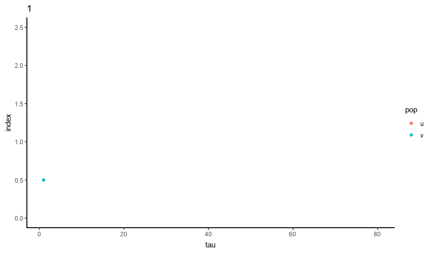

Simuation of u and v over tau based on the modified Euler method

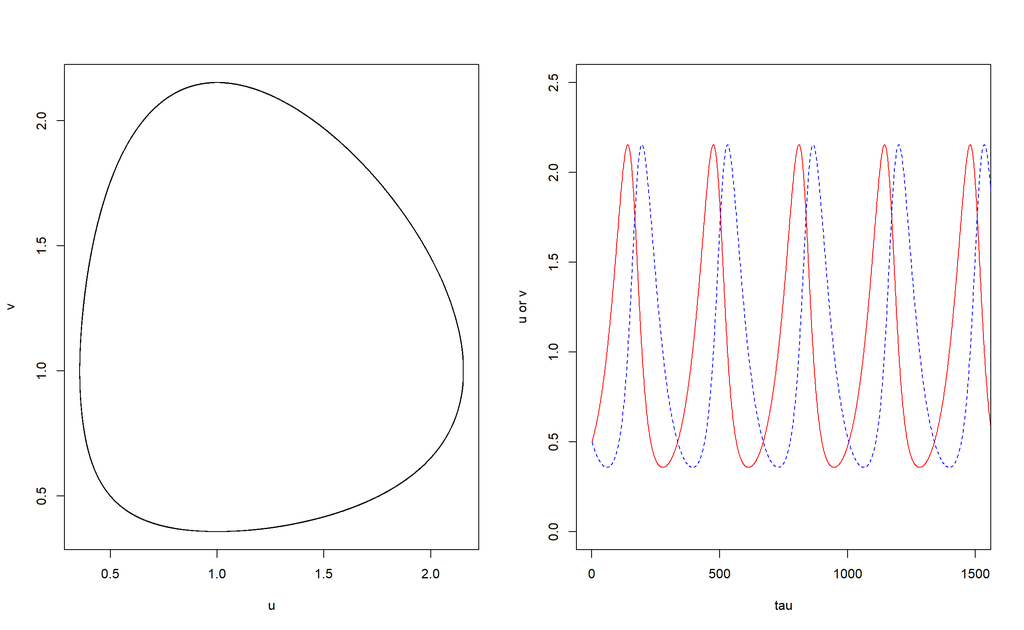

Simulation of two species by modified Euler method with dt = 0.02